# R Notebook

# Preliminaries

Loading libraries and data.

```r
library(EFA.dimensions)
```

Organizing and “wrangling” data.

```r
# Print the column names to verify
print(colnames(survey_items_with_pair))
```

```
[1] "F-Informal"     "F-Provisional"  "F-Unfinished"   "F-Tentative"    "F-Uncertainty"  "F-Alternatives"
[7] "F-Suggestions"  "Pair Seen"
```

# Preparing for EFA

Determine whether these data are appropriate for factor analysis and, if so, how many factors should be used.

```r
# Checking for suitability of factor analysis

# Bartlett's test of sphericity
bartlett_result <- cortest.bartlett(cor(survey_items), n = nrow(survey_items))
print(bartlett_result)
```

```
$chisq
[1] 238.0261

$p.value
[1] 1.03015e-38

$df
[1] 21
```

```r
# Kaiser-Meyer-Olkin (KMO) measure of sampling adequacy
kmo_result <- KMO(cor(survey_items))
print(kmo_result)
```

```
Kaiser-Meyer-Olkin factor adequacy
Call: KMO(r = cor(survey_items))
Overall MSA =  0.77
MSA for each item =
    F-Informal  F-Provisional   F-Unfinished    F-Tentative  F-Uncertainty F-Alternatives
          0.59           0.57           0.76           0.77           0.79           0.86
 F-Suggestions
          0.82
```

The Bartlett’s sphericity results look solid. The KMO numbers for Informal and for Provisional are pretty low. However, the overall MSA (0.77) is acceptable.

Now consider how many factors to use.

```r
DIMTESTS(survey_items,
         tests = c('CD','EMPKC','HULL','MAP','NEVALSGT1','RAWPAR','SESCREE','SMT'),
         corkind = 'pearson',
         display = 2)
```

```
COMPARISON DATA

The number of factors according to the Comparison Data test (from EFAtools) = 1



EMPIRICAL KAISER CRITERION

Kind of correlations analyzed: from user
```

```
    Nfactors    Eigenvalue    Reference Values
           1         3.268               1.606
           2         1.175               1.444
           3         0.899               1.269
           4         0.650               1.077
           5         0.414               1.000
           6         0.354               1.000
           7         0.241               1.000
```

```
The number of factors according to the Empirical Kaiser Criterion = 1

Warning: ! Suggested maximum number of factors was 2 but must be at least 3 for hull method to work. Setting it to 3.
Warning: ! Less than three solutions located on the hull have been identified when using CAF as goodness of fit index. Proceeding by taking the value with the maximum CAF as heuristic. You may want to consider additional indices or methods as robustness check.


HULL METHOD

The number of factors according to the Hull method test (from EFAtools) = 1



MINIMUM AVERAGE PARTIAL (MAP) TEST

The entered data is a correlation matrix.

Number of cases = 98

Number of variables = 7

Specified kind of correlations for this analysis: from user


Total Variance Explained (Initial Eigenvalues):
```

```
            Eigenvalues    Proportion of Variance    Cumulative Prop. Variance
Factor 1           3.27                      0.47                         0.47
Factor 2           1.17                      0.17                         0.63
Factor 3           0.90                      0.13                         0.76
Factor 4           0.65                      0.09                         0.86
Factor 5           0.41                      0.06                         0.92
Factor 6           0.35                      0.05                         0.97
Factor 7           0.24                      0.03                         1.00
```

```
Velicer's Average Squared Correlations
```

```
   root   Avg.Corr.Sq.   Avg.Corr.power4
      0        0.15818           0.04591
      1        0.05677           0.00552
      2        0.09364           0.02170
      3        0.15888           0.08047
      4        0.29691           0.16473
      5        0.52589           0.38689
      6        1.00000           1.00000
```

```
The smallest average squared correlation is 0.05677

The smallest average 4rth power correlation is 0.00552

The number of components according to the original (1976) MAP Test is = 1

The number of components according to the revised (2000) MAP Test is = 1



NUMBER OF EIGENVALUES > 1

The entered data is a correlation matrix.

Number of cases in the data file = 98

Number of variables in the data file = 7

Specified kind of correlations for this analysis: from user



Total Variance Explained (Initial Eigenvalues):
```

```
            Eigenvalues    Proportion of Variance    Cumulative Prop. Variance
Factor 1           3.27                      0.47                         0.47
Factor 2           1.17                      0.17                         0.63
Factor 3           0.90                      0.13                         0.76
Factor 4           0.65                      0.09                         0.86
Factor 5           0.41                      0.06                         0.92
Factor 6           0.35                      0.05                         0.97
Factor 7           0.24                      0.03                         1.00
```

```
The number of eigenvalues greater than one = 2



PARALLEL ANALYSIS

The entered data is a correlation matrix.

Randomization method: generated data

Type of correlations specified for the real data eigenvalues: from user

Type of correlations specified for the random data eigenvalues: pearson

Extraction Method: Principal Components

Variables = 7

Cases = 98

Ndatasets = 100

Percentile = 95

Compare the Real Data eigenvalues below to the corresponding
random data Mean and Percentile eigenvalues
```

```
   Root   Real Data    Mean   Percentile
      1       3.268   1.397        1.553
      2       1.175   1.223        1.317
      3       0.899   1.094        1.164
      4       0.650   0.979        1.038
      5       0.414   0.878        0.945
      6       0.354   0.775        0.853
      7       0.241   0.654        0.730
```

```
The number of factors according to the parallel analysis = 1




STANDARD ERROR SCREE TEST:

Specified kind of correlations for this analysis: from user

The SE Estimate must be > the following value
for a component to be nontrivial: 0.142857142857143
```

```
   Root   Eigenvalue   Slope   SE Estimate
      1         3.27   -0.40          0.66
      2         1.17   -0.19          0.09
      3         0.90   -0.16          0.07
      4         0.65   -0.13          0.06
      5         0.41   -0.09          0.02
```

```
The number of factors according to the standard error scree test = 1



SEQUENTIAL CHI-SQUARE MODEL TEST

Specified kind of correlations for this analysis: from user

The number of factors according to the sequential chi-square model test= 3
```

```
    Nfactors    eigenvalue    Chi-Square    df      pvalue
           0            NA    238.026060    21    0.000000
           1      3.267862     37.484282    14    0.000623
           2      1.174783     21.707488     8    0.005488
           3      0.898633      4.237056     3    0.236978
```

```
DIMTESTS results:
```

```
          # of Factors:
CD                    1
EMPKC                 1
HULL                  1
MAP                   1
NEVALSGT1             2
RAWPAR                1
SESCREE               1
SMT                   3
```

There’s a pretty screar consensus that 1 factor is the way to go.

```
Parallel analysis suggests that the number of factors =  2  and the number of components =  NA
```

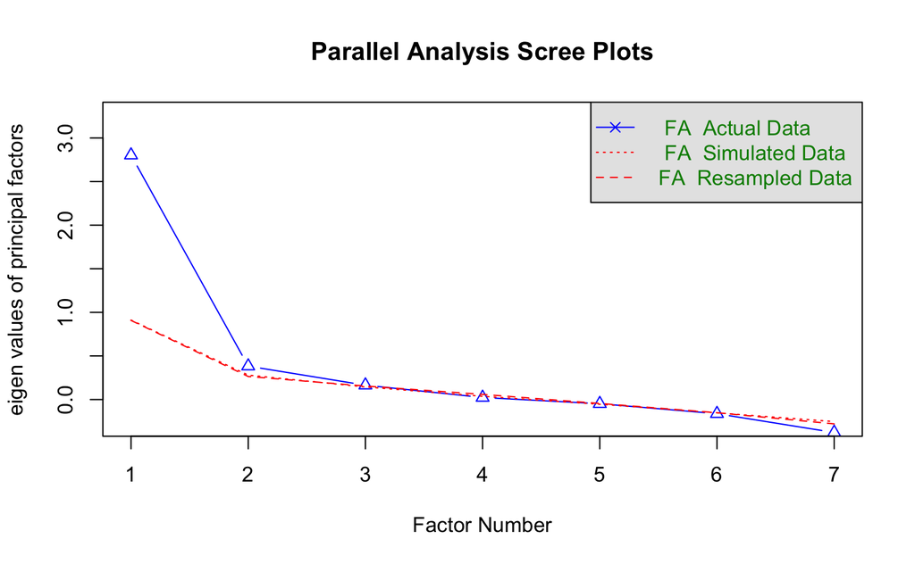

```r
# Conducting Factor Analysis
# Decide on the number of factors using parallel analysis
fa_parallel <- fa.parallel(survey_items, fm = "ml", fa = "fa")
```

```r
print(fa_parallel)
```

```
Call: fa.parallel(x = survey_items, fm = "ml", fa = "fa")
Parallel analysis suggests that the number of factors =  2  and the number of components =  NA

 Eigen Values of

 eigen values of factors
[1]  2.80  0.38  0.16  0.02 -0.05 -0.16 -0.38

 eigen values of simulated factors
[1]  0.91  0.28  0.14  0.04 -0.05 -0.15 -0.25

 eigen values of components
[1] 3.27 1.17 0.90 0.65 0.41 0.35 0.24

 eigen values of simulated components
[1] NA
```

We’ll proceed with one factor.

# Conducting EFA

Conduct factor analysis with the suggested number of factors (i.e., one factor).

```r
print(fa_result)
```

```
Factor Analysis using method =  pa
Call: fa(r = survey_items, nfactors = 1, rotate = "oblimin", fm = "pa")
Standardized loadings (pattern matrix) based upon correlation matrix
```

|  | PA1 | h2 | u2 | com |
| --- | --- | --- | --- | --- |
| F-Informal | 0.31 | 0.09421351 | 0.9057865 | 1 |
| F-Provisional | 0.27 | 0.07230589 | 0.9276941 | 1 |
| F-Unfinished | 0.79 | 0.62609223 | 0.3739078 | 1 |
| F-Tentative | 0.55 | 0.30565058 | 0.6943494 | 1 |
| F-Uncertainty | 0.87 | 0.75170859 | 0.2482914 | 1 |
| F-Alternatives | 0.69 | 0.48081142 | 0.5191886 | 1 |
| F-Suggestions | 0.68 | 0.46376185 | 0.5362381 | 1 |

```
                PA1
SS loadings    2.79
Proportion Var 0.40

Mean item complexity =  1
Test of the hypothesis that 1 factor is sufficient.

df null model =  21  with the objective function =  2.54 with Chi Square =  238.03
df of  the model are 14  and the objective function was  0.41

The root mean square of the residuals (RMSR) is  0.09
The df corrected root mean square of the residuals is  0.11

The harmonic n.obs is  98 with the empirical chi square  33.68  with prob <  0.0023
The total n.obs was  98  with Likelihood Chi Square =  38.24  with prob <  0.00048

Tucker Lewis Index of factoring reliability =  0.831
RMSEA index =  0.133  and the 90 % confidence intervals are  0.084 0.185
BIC =  -25.95
Fit based upon off diagonal values = 0.95
Measures of factor score adequacy
                                                   PA1
Correlation of (regression) scores with factors   0.94
Multiple R square of scores with factors          0.88
Minimum correlation of possible factor scores     0.75
```

Looks like Provisional and Informal aren’t all that central (which is perhaps unsurprising, given their individual MSA from KMO test). However, the remaining items are clearly part of a single consistent and interpretable factor.

Let’s add that resulting factor value back into our original data frame.

# ANOVA

Now we’ll see how the single factor differs across conditions.

```r
f1.mod <- aov(Factor1 ~ `Rendering` * `Visualization Seen`, data=df)
summary(f1.mod)
```

```
                               Df Sum Sq Mean Sq F value  Pr(>F)
Rendering                       1   2.87   2.866   3.580 0.06154 .
`Visualization Seen`            1   5.80   5.795   7.239 0.00844 **
Rendering:`Visualization Seen`  1   1.01   1.013   1.265 0.26363
Residuals                      94  75.26   0.801
---
Signif. codes:  0 ‘***’ 0.001 ‘**’ 0.01 ‘*’ 0.05 ‘.’ 0.1 ‘ ’ 1
```

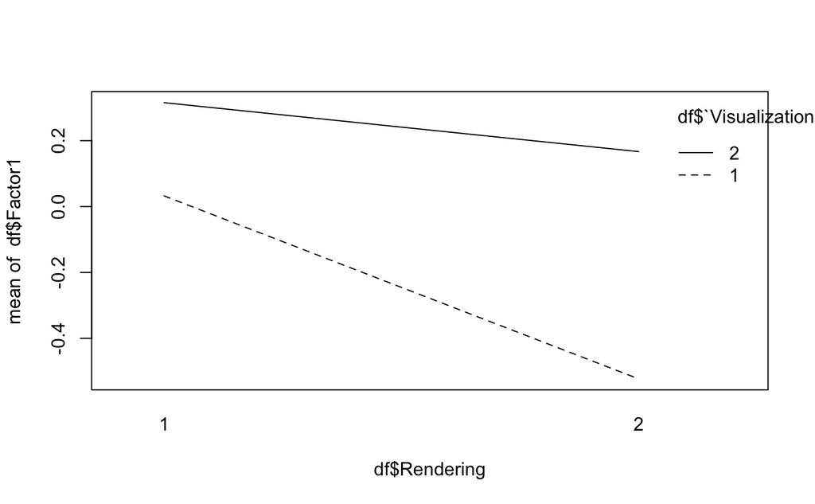

```r
interaction.plot(df$Rendering, df$`Visualization Seen`, df$Factor1)
```

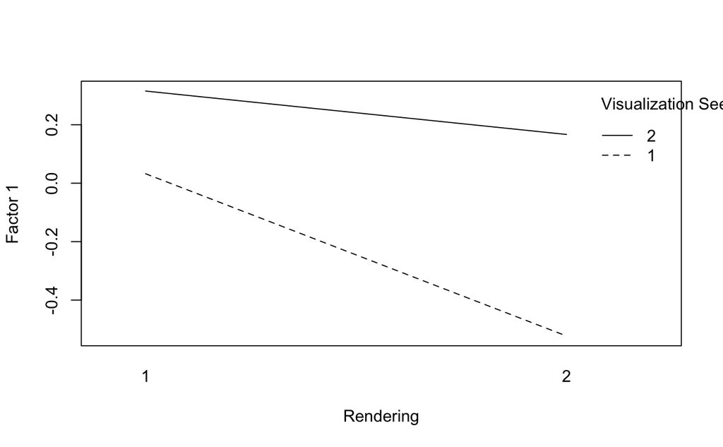

```r
interaction.plot(df$`Rendering`, df$`Visualization Seen`, df$Factor1,
                   xlab = "Rendering", ylab = "Factor 1",
                   trace.label = "Visualization Seen")
```

Looks like, for Vis == 1, there’s a clear difference in Factor1. There’s less of a clear difference in Factor1 for Vis == 2, but the ANOVA results suggest this is a non-significant interaction.

Interestingly, there is a near-significant main effect for Rendering, but the most significant effect is for which Visualization the participant saw.

# Alternative with Fewer Items

However, what if we drop Provisional and Informal, since they’re not as central to the resulting factors, then re-run EFA?

```r
# drop the two items
survey_items.reduced <- subset(survey_items, select = -c(`F-Provisional`, `F-Informal`))
df.reduced <- subset(df, select = -c(`F-Provisional`, `F-Informal`))

# now re-run EFA
fa_result.reduced <- fa(survey_items.reduced, nfactors = 1, fm = "pa", rotate = "oblimin")
print(fa_result.reduced)
```

```
Factor Analysis using method =  pa
Call: fa(r = survey_items.reduced, nfactors = 1, rotate = "oblimin",
    fm = "pa")
Standardized loadings (pattern matrix) based upon correlation matrix
```

|  | PA1 | h2 | u2 | com |
| --- | --- | --- | --- | --- |
| F-Unfinished | 0.77 | 0.5877714 | 0.4122286 | 1 |
| F-Tentative | 0.52 | 0.2698277 | 0.7301723 | 1 |
| F-Uncertainty | 0.89 | 0.7992022 | 0.2007978 | 1 |
| F-Alternatives | 0.71 | 0.5078693 | 0.4921307 | 1 |
| F-Suggestions | 0.70 | 0.4866341 | 0.5133659 | 1 |

```
                PA1
SS loadings    2.65
Proportion Var 0.53

Mean item complexity =  1
Test of the hypothesis that 1 factor is sufficient.

df null model =  10  with the objective function =  2.12 with Chi Square =  200.21
df of  the model are 5  and the objective function was  0.1

The root mean square of the residuals (RMSR) is  0.05
The df corrected root mean square of the residuals is  0.07

The harmonic n.obs is  98 with the empirical chi square  5.06  with prob <  0.41
The total n.obs was  98  with Likelihood Chi Square =  9.36  with prob <  0.096

Tucker Lewis Index of factoring reliability =  0.954
RMSEA index =  0.094  and the 90 % confidence intervals are  0 0.188
BIC =  -13.56
Fit based upon off diagonal values = 0.99
Measures of factor score adequacy
                                                   PA1
Correlation of (regression) scores with factors   0.94
Multiple R square of scores with factors          0.89
Minimum correlation of possible factor scores     0.77
```

No major differences in the factor loadings.

Now what about the ANOVA results?

```r
df.reduced$Factor1 <- fa_result.reduced$scores[,1]

f1.reduced.mod <- aov(Factor1 ~ `Rendering` * `Visualization Seen`, data=df.reduced)
summary(f1.reduced.mod)
```

```
                               Df Sum Sq Mean Sq F value  Pr(>F)
Rendering                       1   2.54   2.537   3.173 0.07808 .
`Visualization Seen`            1   7.20   7.202   9.010 0.00344 **
Rendering:`Visualization Seen`  1   1.02   1.021   1.278 0.26116
Residuals                      94  75.14   0.799
---
Signif. codes:  0 ‘***’ 0.001 ‘**’ 0.01 ‘*’ 0.05 ‘.’ 0.1 ‘ ’ 1
```

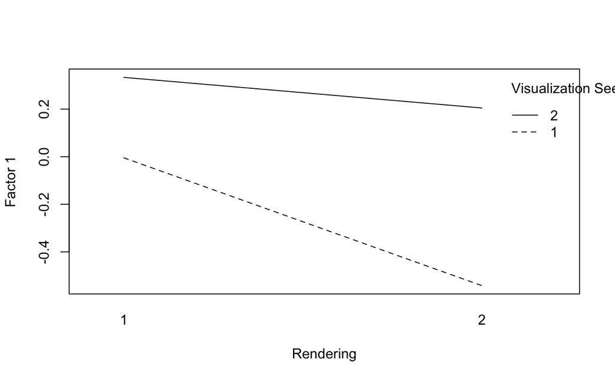

```r
interaction.plot(df.reduced$`Rendering`, df.reduced$`Visualization Seen`, df.reduced$Factor1,
                   xlab = "Rendering", ylab = "Factor 1",
                   trace.label = "Visualization Seen")
```

Overall the same pattern. The effect of the rendering is now less close to significant.

Probably makes more sense just to retain all 7 items.